# Effect of tank order on siamese fish behaviour

Author

Juliette Tariel-Adam

Published

February 4, 2025

Order in which the fish experienced the tanks. Fish underwent different order of treatments: Some fish started with Large, then Small, etc; Other fish with Medium, then Jar, etc. Barren was the last tank = 5th tank for all fish. Is there an effect of the order of treatments? For instance, were fish more swimming on average during the 1st or 2nd tank they went in?

A problem because all fish last experienced Barren, we cannot disentangle the effect of Barren from the effect of order. Maybe all the changes in behaviour in Barren were only because it was the last tank the fish went into. At least, we are comparing Large and Barren, as Large is not always the 4th tank, we are not always comparing the same tank orders when comparing Large and Barren.

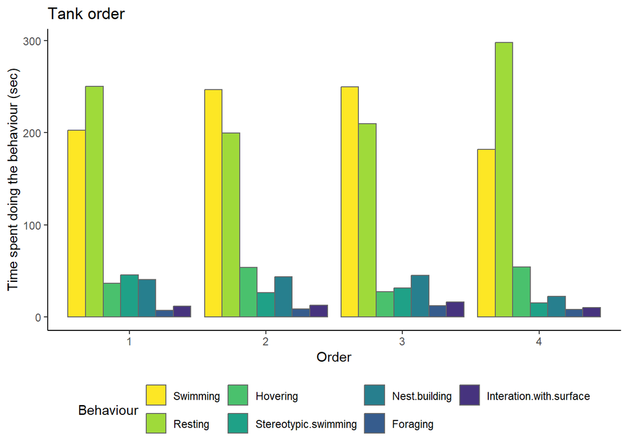

```r
data %>% filter(Tank != "Barren") %>%
  plot1("Order", main = .) +
  ggtitle("Tank order")
```

# Swimming

Treat tank order as a continuous or categorical variable?

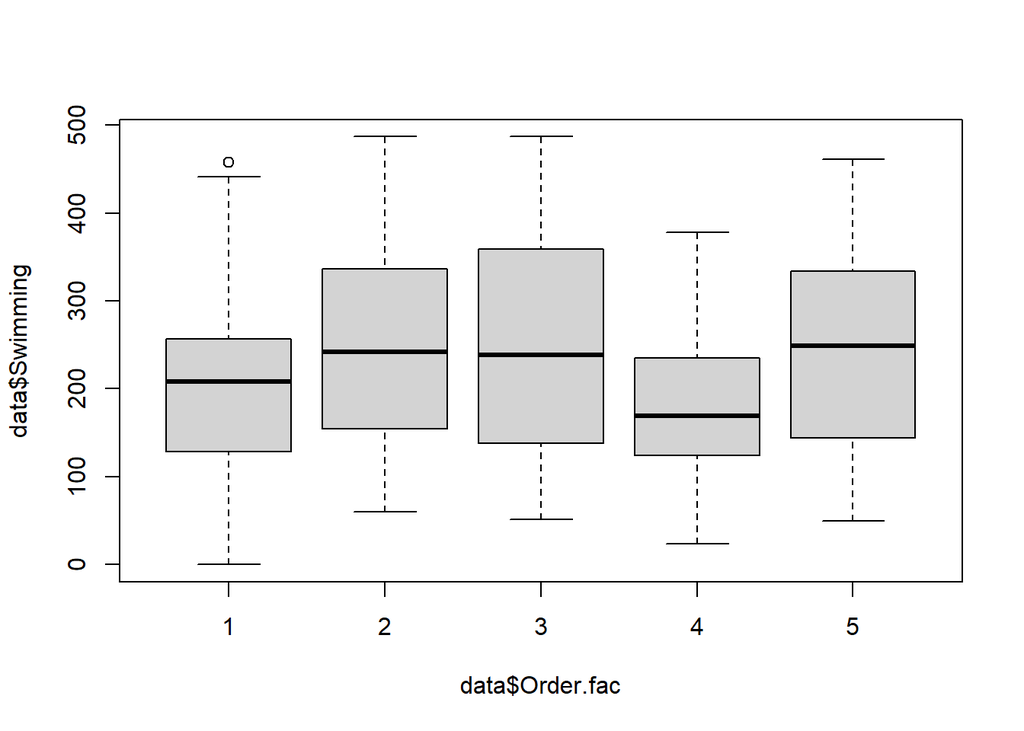

```r
plot(data$Swimming ~ data$Order.fac)
```

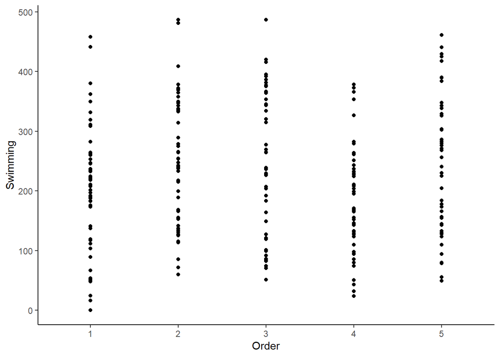

```r
ggplot(data, aes(y = Swimming, x = Order)) + geom_point() + geom_smooth()
```

Considering the plot of the relationship between Swimming and Tank order (no linear relationship), tank order is better as a categorical variable.

After, comparison of models with or without tank order, on the full or subset dataset without Barren.

```r
# With tank order on data without Barren
mOrder.Swimming.subset <- lmer(Swimming ~ Tank + Time + Filter + Order.fac + (1|Fish), data = filter(data, Tank !="Barren"))
anova(mOrder.Swimming.subset , ddf = "Kenward-Roger", type = 2)
```

```
Type II Analysis of Variance Table with Kenward-Roger's method
          Sum Sq Mean Sq NumDF  DenDF F value    Pr(>F)
Tank      221999   74000     3 186.51 14.9390 9.339e-09 ***
Time      280876   93625     3 181.03 18.9026 1.039e-10 ***
Filter     49584   49584     1 167.19 10.0107  0.001849 **
Order.fac  66288   22096     3 183.03  4.4611  0.004742 **
---
Signif. codes:  0 '***' 0.001 '**' 0.01 '*' 0.05 '.' 0.1 ' ' 1
```

```r
emmeans(mOrder.Swimming.subset, ~ Tank) %>%
  contrast(.,
           list(jar_vs_small     = c(1,-1, 0, 0),
                jar_vs_medium    = c(1, 0,-1, 0),
                jar_vs_large     = c(1, 0, 0,-1),
                small_vs_medium  = c(0, 1,-1, 0),
                small_vs_large   = c(0, 1, 0,-1),
                medium_vs_large  = c(0, 0, 1,-1)),
           adjust = "holm")
```

```
 contrast        estimate   SE  df t.ratio p.value
 jar_vs_small      -18.11 14.3 182  -1.268  0.6191
 jar_vs_medium     -21.09 17.0 191  -1.239  0.6191
 jar_vs_large      -95.84 16.7 190  -5.739  <.0001
 small_vs_medium    -2.98 16.6 192  -0.180  0.8574
 small_vs_large    -77.73 16.4 191  -4.739  <.0001
 medium_vs_large   -74.75 13.9 181  -5.364  <.0001

Results are averaged over the levels of: Time, Filter, Order.fac
Degrees-of-freedom method: kenward-roger
P value adjustment: holm method for 6 tests
```

```r
# Without tank order on data without Barren
mSwimming.subset <-lmer(Swimming ~ Tank + Time + Filter + (1|Fish), data = filter(data, Tank !="Barren"))
anova(mSwimming.subset , ddf = "Kenward-Roger", type = 2)
```

```
Type II Analysis of Variance Table with Kenward-Roger's method
       Sum Sq Mean Sq NumDF  DenDF F value    Pr(>F)
Tank   238424   79475     3 189.62  15.143 7.100e-09 ***
Time   280876   93625     3 184.03  17.841 3.299e-10 ***
Filter  86224   86224     1 168.97  16.431 7.684e-05 ***
---
Signif. codes:  0 '***' 0.001 '**' 0.01 '*' 0.05 '.' 0.1 ' ' 1
```

```r
AIC(mOrder.Swimming.subset , mSwimming.subset)
```

```
                       df      AIC
mOrder.Swimming.subset 13 2277.207
mSwimming.subset       10 2305.114
```

```r
# With tank order on all data
mOrder.Swimming <-lmer(Swimming ~ Tank + Time + Filter + Order.fac + (1|Fish), data = data)
```

```
fixed-effect model matrix is rank deficient so dropping 1 column / coefficient
```

```r
anova(mOrder.Swimming , ddf = "Kenward-Roger", type = 2)
```

```
Type II Analysis of Variance Table with Kenward-Roger's method
          Sum Sq Mean Sq NumDF  DenDF F value    Pr(>F)
Tank      219905   54976     4 233.88  9.5912 3.376e-07 ***
Time      337219  112406     3 228.04 19.6133 2.393e-11 ***
Filter     71734   71734     1 152.69 12.5166 0.0005346 ***
Order.fac  68083   22694     3 230.47  3.9598 0.0088524 **
---
Signif. codes:  0 '***' 0.001 '**' 0.01 '*' 0.05 '.' 0.1 ' ' 1
```

```r
## Contrasts among Jar, Small, Medium and Large over Orders 1 to 4
emmeans(mOrder.Swimming, ~ Tank ,
                       at = list(Tank = c("Jar", "Small", "Medium", "Large"),
                                 Order.fac = c("1", "2", "3", "4"))) %>%
  contrast(.,
           list(jar_vs_small     = c(1,-1, 0, 0),
                jar_vs_medium    = c(1, 0,-1, 0),
                jar_vs_large     = c(1, 0, 0,-1),
                small_vs_medium  = c(0, 1,-1, 0),
                small_vs_large   = c(0, 1, 0,-1),
                medium_vs_large  = c(0, 0, 1,-1)),
           adjust = "holm")
```

```
 contrast        estimate   SE  df t.ratio p.value
 jar_vs_small     -16.468 15.3 229  -1.074  0.8523
 jar_vs_medium    -17.203 17.7 240  -0.971  0.8523
 jar_vs_large     -92.070 17.4 239  -5.286  <.0001
 small_vs_medium   -0.735 17.3 240  -0.043  0.9661
 small_vs_large   -75.602 17.1 240  -4.413  0.0001
 medium_vs_large  -74.868 15.0 228  -4.995  <.0001

Results are averaged over the levels of: Time, Filter, Order.fac
Degrees-of-freedom method: kenward-roger
P value adjustment: holm method for 6 tests
```

```r
## Contrasts between Large (over Orders 1 to 4) and Barren
emm1 <- emmeans(mOrder.Swimming, ~ Tank ,
                       at = list(Tank = c("Large"),
                                 Order.fac = c("1", "2", "3", "4")))
emm2 <- emmeans(mOrder.Swimming, ~ Tank ,
                       at = list(Tank = c("Barren"),
                                 Order.fac = c("5")))
contrast(rbind(emm1,emm2), list(large_vs_barren= c(1,-1)))
```

```
 contrast        estimate   SE  df t.ratio p.value
 large_vs_barren     53.4 15.3 229   3.494  0.0006

Results are averaged over some or all of the levels of: Time, Filter, Order.fac
Degrees-of-freedom method: kenward-roger
```

```r
## Estimated means for Orders 1 to 4
emm1 <- emmeans(mOrder.Swimming, ~ Order.fac,
                       at = list(Order.fac = c("1", "2", "3", "4")))

# Without tank order on all data
mSwimming <-lmer(Swimming ~ Tank + Time + Filter + (1|Fish), data = data)

AIC(mOrder.Swimming,mSwimming)
```

```
                df      AIC
mOrder.Swimming 14 2851.958
mSwimming       11 2878.882
```

Significant effect of tank order + The best model is the one with tank order (in terms of AIC) on the full dataset or dataset without Barren => Tank order needs to be included in the model…

Good news:

- I found a way to calculate contrasts among Jar, Small, Medium and Large on the model with all data!
- I found a way to calculate the contrast between contrast Large (estimated across Orders 1 to 4) and Barren at Order 5.
- Still an effect of tank when tank order is included

# Resting

```r
# with tank order
mOrder.Resting <- lmer(Resting ~ Tank + Time + Filter + Order.fac + (1|Fish), data = data)
```

```
fixed-effect model matrix is rank deficient so dropping 1 column / coefficient
```

```r
anova(mOrder.Resting, ddf = "Kenward-Roger", type = 2)
```

```
Type II Analysis of Variance Table with Kenward-Roger's method
          Sum Sq Mean Sq NumDF  DenDF F value    Pr(>F)
Tank      493242  123311     4 232.15  9.9054 2.041e-07 ***
Time      795993  265331     3 228.01 21.3145 3.308e-12 ***
Filter         1       1     1 224.03  0.0001 0.9936214
Order.fac 218417   72806     3 229.40  5.8486 0.0007258 ***
---
Signif. codes:  0 '***' 0.001 '**' 0.01 '*' 0.05 '.' 0.1 ' ' 1
```

```r
# without tank order
mResting <- lmer(Resting ~ Tank + Time + Filter + (1|Fish), data = data)

AIC(mOrder.Resting, mResting)
```

```
               df      AIC
mOrder.Resting 14 3047.644
mResting       11 3082.241
```

Idem Swimming

# Foraging

```r
mOrder.Foraging <- glmmTMB(Foraging.bin ~ Tank + Time + Filter + Order.fac + (1|Fish), data = data, family =binomial, control = glmmTMBControl(rank_check = "adjust"))
```

```
dropping columns from rank-deficient conditional model: Order.fac5
```

```r
glmmTMB:::Anova.glmmTMB(mOrder.Foraging)
```

```
Analysis of Deviance Table (Type II Wald chisquare tests)

Response: Foraging.bin
            Chisq Df Pr(>Chisq)
Tank      31.4734  4  2.451e-06 ***
Time       1.8543  3     0.6032
Filter     0.4113  1     0.5213
Order.fac  4.5561  3     0.2073
---
Signif. codes:  0 '***' 0.001 '**' 0.01 '*' 0.05 '.' 0.1 ' ' 1
```

```r
mForaging <- glmmTMB(Foraging.bin ~ Tank + Time + Filter + (1|Fish), data = data, family =binomial)

AIC(mOrder.Foraging,mForaging)
```

```
                df      AIC
mOrder.Foraging 13 281.8794
mForaging       10 280.6847
```

The model is better without Tank order + no effect of tank order. Still a significant effect of Tank with Tank order in the model.

# Nest building

```r
mOrder.Nesting <- glmmTMB(Nest.bin ~ Tank + Time + Filter + Order.fac + (1|Fish), data = data, family =binomial, control = glmmTMBControl(rank_check = "adjust"))
```

```
dropping columns from rank-deficient conditional model: Order.fac5
```

```r
glmmTMB:::Anova.glmmTMB(mOrder.Nesting)
```

```
Analysis of Deviance Table (Type II Wald chisquare tests)

Response: Nest.bin
            Chisq Df Pr(>Chisq)
Tank       8.6944  4  0.0692076 .
Time       7.3587  3  0.0613014 .
Filter    11.7652  1  0.0006035 ***
Order.fac  4.6506  3  0.1992406
---
Signif. codes:  0 '***' 0.001 '**' 0.01 '*' 0.05 '.' 0.1 ' ' 1
```

```r
mNesting <- glmmTMB(Nest.bin ~ Tank + Time + Filter + (1|Fish), data = data, family =binomial)

AIC(mOrder.Nesting,mNesting)
```

```
               df      AIC
mOrder.Nesting 13 229.7846
mNesting       10 228.6833
```

Idem Foraging, the model is better without Tank order + no effect of tank order. However, keeping Tank order removes the significant effect of Tank on Nest Building

# Stereotypic Swimming

```r
mOrder.SS <- glmmTMB(SS.bin ~ Tank + Time + Filter + Order.fac + (1|Fish), data = data, family =binomial, control = glmmTMBControl(rank_check = "adjust"))
```

```
dropping columns from rank-deficient conditional model: Order.fac5
```

```r
glmmTMB:::Anova.glmmTMB(mOrder.SS)
```

```
Analysis of Deviance Table (Type II Wald chisquare tests)

Response: SS.bin
            Chisq Df Pr(>Chisq)
Tank      22.3290  4  0.0001723 ***
Time       3.1486  3  0.3692807
Filter     1.7487  1  0.1860451
Order.fac  2.7610  3  0.4299628
---
Signif. codes:  0 '***' 0.001 '**' 0.01 '*' 0.05 '.' 0.1 ' ' 1
```

```r
mSS <- glmmTMB(SS.bin ~ Tank + Time + Filter + (1|Fish), data = data, family =binomial)

AIC(mOrder.SS,mSS)
```

```
          df      AIC
mOrder.SS 13 208.9245
mSS       10 205.7593
```

Idem Foraging